# Named Probability Distributions

Yuji Saikai ysaikai@unimelb.edu.au School of Mathematics and Statistics The University of Melbourne

These notes are based on Chapter 15 & 16 of JMR — Jones, O., Maillardet, R., & Robinson, A. (2009). *Introduction to scientific programming and simulation using R*. CRC Press.

Building upon probability theory, we are going to study specific probability distributions in these notes. They are so common and/or important that each has got a name and dedicated R built-in functions. Although at some point we may need to create special distributions and write associated functions for our models, it is often sufficient to combine the existing ones as building blocks.

# Discrete distributions

R recognises common distributions by short names and specifies them by parameters.

| Distribution | R name | R Parameters | Abbreviation |
| --- | --- | --- | --- |
| Bernoulli | `binom` | `size=1`, `prob` | $\mathrm{Bernoulli}(p)$ |
| Binomial | `binom` | `size`, `prob` | $\mathrm{binom}(n,p)$ |
| Geometric | `geom` | `prob` | $\mathrm{geom}(p)$ |
| Negative binomial | `nbinom` | `size`, `prob` | $\mathrm{nbinom}(r,p)$ |
| Poisson | `pois` | `lambda` | $\mathrm{pois}(\lambda)$ |

> $\mathrm{Bernoulli}(p)$ is equivalent to $\mathrm{binom}(1,p)$.

R built-in functions for common distributions follow a certain pattern. Suppose that a distribution is recognised by name `xyz` and specified by parameters `p1` and `p2`, then R provides the following four functions to help you work with the distribution.

- `dxyz(x, p1, p2, ...)` returns $P(X=x)$, the value of PMF at $x$.
- `pxyz(q, p1, p2, ...)` returns $F(q)$, the value of CDF at $q$.
- `qxyz(p, p1, p2, ...)` returns $\operatorname{argmin}_x F(x)\geq p$, i.e., the [quantile function](https://en.wikipedia.org/wiki/Quantile_function).
- `rxyz(n, p1, p2, ...)` returns $n$ random samples.

> There are lots of $p$ used throughout these notes. So, I avoid $p(x)$ but use $P(X=x)$ to denote the PMF of $X$. Recall that $P(X=x)$ is a shorthand for $P(\{\omega\in\Omega : X(\omega)=x\})$.

The support of discrete $X$ is the set $\{x\in\mathbb{R} : P(X=x)>0\}$.

## Bernoulli

The support is $\{0,1\}$, which is often interpreted as “failure” and “success” respectively. Naturally, it has a single parameter $p\in[0,1]$ that specifies the probability of success $p = P(X=1)$. Bernoulli distribution serves as a building block and, as you will see below, many complex distributions are modelled as a sequence of independent Bernoulli trials.

$$\begin{align}
P(X=x) &=
\begin{cases}
p & \text{for } x=1\\
1 - p & \text{for } x=0
\end{cases}\\\\
\mathbb{E}X &= \sum_{x\in\{0,1\}} xP(X=x)\\
&= 0\cdot(1-p)+1\cdot p\\
&= p\\\\
\operatorname{Var} X &= \sum_{x\in\{0,1\}} (x-p)^2P(X=x)\\
&= (0-p)^2\cdot(1-p) + (1-p)^2\cdot p\\
&= p(1-p)
\end{align}$$

## Binomial

Imagine doing independent $\mathrm{Bernoulli}(p)$ trials $n$ times. Let $X$ denote the number of $1$s from $n$ trials. Then, $X\sim \text{binom}(n,p)$. Formally, let $B_1,\dots,B_n \sim \text{Bernoulli}(p)$. Then,
$$X = B_1+\dots+B_n,$$
with the support $\{0,1,\dots,n\}$. In deriving the PMF, key computation is to count the number of ways to choose $x$ trials that turn out $1$ from the total $n$ trials, called the [binomial coefficient](https://en.wikipedia.org/wiki/Binomial_coefficient) and commonly denoted by $\binom{n}{x}$.

$$\begin{align}
P(X=x) &= \binom{n}{x}p^x(1-p)^{n-x}\\\\
\mathbb{E}X &= \mathbb{E}(B_1+\dots+B_n)\\
&= \mathbb{E}B_1+\dots+\mathbb{E}B_n\\
&= np\\\\
\operatorname{Var} X &= \operatorname{Var}(B_1+\dots+B_n)\\
&= \operatorname{Var}B_1+\dots+\operatorname{Var}B_n\\
&= np(1-p)
\end{align}$$

> $\operatorname{Var} X$ formula is drived by exploiting $n$ **independent** Bernoulli trials.

Here are some of PMF plots with varying $p$.

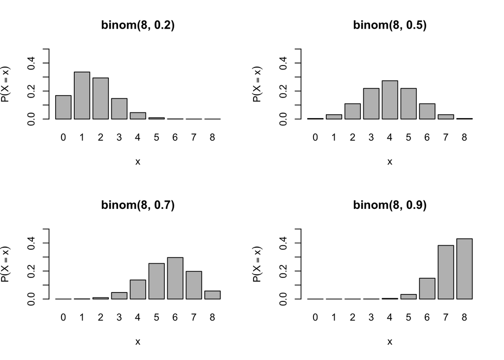

```r
n <- 8
x <- 0:n
myplot <- function(p) {
  barplot(dbinom(x,n,p),
          names.arg = x,
          ylim=c(0,.5),
          main=paste("binom(",n,", ",p,")", sep=""),
          xlab="x",
          ylab=expression(P(X==x)))
}
par(mfrow=c(2,2))
for (p in c(.2,.5,.7,.9)) {
  myplot(p)
}
```

## Poisson

Imagine doing **many** independent $\mathrm{Bernoulli}(p)$ trials, in each of which success is very rare. For example, the number of car accidents in Melbourne in a single day, where each of thousands of drivers has a very small chance of accident. While we may use $\text{binom}(n,p)$ with large $n$ and small $p$, we could be in trouble because computers cannot handle extremely large or small numbers very well. An alternative modelling option is $\text{pois}(\lambda)$ with $\lambda\approx np$. Here is why.

Let $Y_n \sim \text{binom}(n,p)$ such that $p=\lambda/n$ for some $\lambda>0$. Then,

$$\begin{align}
P(Y_n=x) &= \binom{n}{x}p^x(1-p)^{n-x}\\
&= \frac{n\cdot(n-1)\dotsm(n-x+1)}{x!}\left(\frac{\lambda}{n}\right)^x\left(1-\frac{\lambda}{n}\right)^{n-x}\\
&= 1\cdot\frac{n-1}{n}\dotsm\frac{n-x+1}{n}\frac{\lambda^x}{x!}\left(1-\frac{\lambda}{n}\right)^{n}\left(1-\frac{\lambda}{n}\right)^{-x}\\
&\to 1\cdot 1\dotsm 1\cdot\frac{\lambda^x}{x!}\cdot e^{-\lambda}\cdot 1 \quad\text{as}\quad n\to\infty\\
&= \frac{e^{-\lambda}\lambda^x}{x!},
\end{align}$$

which is the PMF of $\mathrm{pois}(\lambda)$. The limit
$$\lim_{n\to\infty} P(Y_n=x) = \frac{e^{-\lambda}\lambda^x}{x!}$$
is called the *law of rare events*. As indicated by $n\to\infty$, the support is $\mathbb{Z}_{\geq0}=\{0,1,\dots\}$. Both mean and variance are equal to $\lambda$.

An important property of $\text{pois}(\lambda)$ is the following. Suppose $X_1,\dots,X_n$ are independent Poisson random variables with the corresponding parameters $\lambda_1,\dots\lambda_n$. Then,
$$X_1+\dots+X_n \sim \text{pois}(\lambda_1+\dots+\lambda_n).$$
Here is a proof for $n=2$, which lets us generalise to $n>2$ by induction.

$$\begin{align}
P(X_1+X_2=x) &= \sum_{y=0}^x P(X_1=y)P(X_2=x-y)\\
&= \sum_{y=0}^x \frac{e^{-\lambda_1} \lambda_1^y}{y!}\cdot\frac{e^{-\lambda_2} \lambda_2^{x-y}}{(x-y)!}\\
&= \frac{e^{-(\lambda_1+\lambda_2)} (\lambda_1+\lambda_2)^x}{x!} \cdot \sum_{y=0}^x\binom{x}{y}\left(\frac{\lambda_1}{\lambda_1+\lambda_2}\right)^y\left(\frac{\lambda_2}{\lambda_1+\lambda_2}\right)^{x-y}\\
&= \frac{e^{-(\lambda_1+\lambda_2)} (\lambda_1+\lambda_2)^x}{x!}
\end{align}$$

The last equality follows because the summand is the PMF for $\text{binom}\left(x,\frac{\lambda_1}{\lambda_1+\lambda_2}\right)$.

Let’s compare $X\sim \text{pois}(\lambda)$ and $Y\sim \text{binom}(n,p)$ such that $\lambda = np$ where $\lambda=1$ and $n=10^4$.

```r
lambda <- 1
n <- 1e4
x <- c(0,2,5)
```

| $x$ | $P(X=x)$ | $P(Y=x)$ |
| --- | --- | --- |
| 0 | 0.3678794 | 0.367861 |
| 2 | 0.1839397 | 0.1839489 |
| 5 | 0.0030657 | 0.003064 |

Even with a moderate $n$, Poisson provides reasonable approximation of Binomial. Here are some of PMF plots with varying $\lambda$.

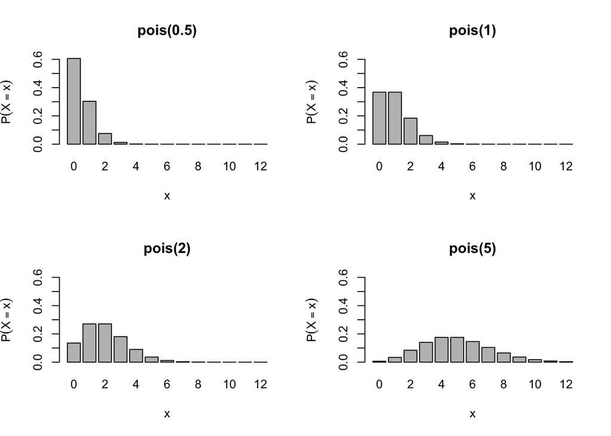

```r
n <- 12
x <- 0:n
myplot <- function(l) {
  barplot(dpois(x,l),
          names.arg = x,
          ylim=c(0,.6),
          main=paste("pois(",l,")", sep=""),
          xlab="x",
          ylab=expression(P(X==x)))
}
par(mfrow=c(2,2))
for (l in c(.5,1,2,5)) {
  myplot(l)
}
```

## Geometric

Imagine doing independent $\mathrm{Bernoulli}(p)$ trials **indefinitely** until we see the first success. Let $X$ denote the number of $0$ before getting the first $1$. Then, $X\sim \text{geom}(p)$.

> Some authors define $X$ to be the number of trials, and we also do so in Poisson process.

Formally, let $B_1,B_2\dots \sim \text{Bernoulli}(p)$. Then,
$$X = \inf\{n\in\mathbb{Z}_{>0} : B_n=1\}-1 .$$
with the support $\mathbb{Z}_{\geq0}=\{0,1,\dots\}$. The derivation of PMF is easier than $\text{binom}(n,p)$, as it simply continues to multiply the failure probability $1-p$ until the last success probability $p$.

$$\begin{align}
P(X=x) &= P(B_1=0,B_2=0,\dots,B_x=0,B_{x+1}=1))\\
&= P(B_1=0) \dotsm P(B_x=0)P(B_{x+1}=1)\\
&= (1-p)^xp\\\\
\mathbb{E}X &= \sum_{x=0}^\infty xP(X=x)\\
&= \sum_{x=0}^\infty x(1-p)^xp\\
&= p(1-p)\sum_{x=0}^\infty x(1-p)^{x-1}\\
&= p(1-p)\left(-\sum_{x=0}^\infty \frac{d}{dp}(1-p)^{x}\right)\\
&= p(1-p)\frac{d}{dp}\left(-\sum_{x=0}^\infty (1-p)^{x}\right)\\
&= p(1-p)\frac{d}{dp}\left(-\frac{1}{p}\right)\\
&= \frac{1-p}{p}
\end{align}$$

For the variance, let’s first compute $\mathbb{E}[X(X-1)]$.
$$\begin{align}
\mathbb{E}[X(X-1)]
&= \sum_{x=0}^\infty x(x-1)(1-p)^xp\\
&= \sum_{x=0}^\infty p(1-p)^2x(x-1)(1-p)^{x-2}\\
&= p(1-p)^2 \sum_{x=0}^\infty \frac{d^2}{dp^2}(1-p)^{x}\\
&= p(1-p)^2 \frac{d^2}{dp^2}\sum_{x=0}^\infty (1-p)^{x}\\
&= p(1-p)^2 \frac{d^2}{dp^2}\frac{1}{p}\\
&= \frac{2(1-p)^2}{p^2}\\
\end{align}$$

Now,
$$\begin{align}
\operatorname{Var} X
&= \mathbb{E}X^2 - (\mathbb{E}X)^2\\
&= \mathbb{E}[X(X-1)] + \mathbb{E}X - (\mathbb{E}X)^2\\
&= \frac{2(1-p)^2}{p^2} + \frac{1-p}{p} - \frac{(1-p)^2}{p^2}\\
&= \frac{1-p}{p^2}
\end{align}$$

> We may interchange the order of summation and differentiation in geometric series.

Here are some of PMF plots with varying $p$.

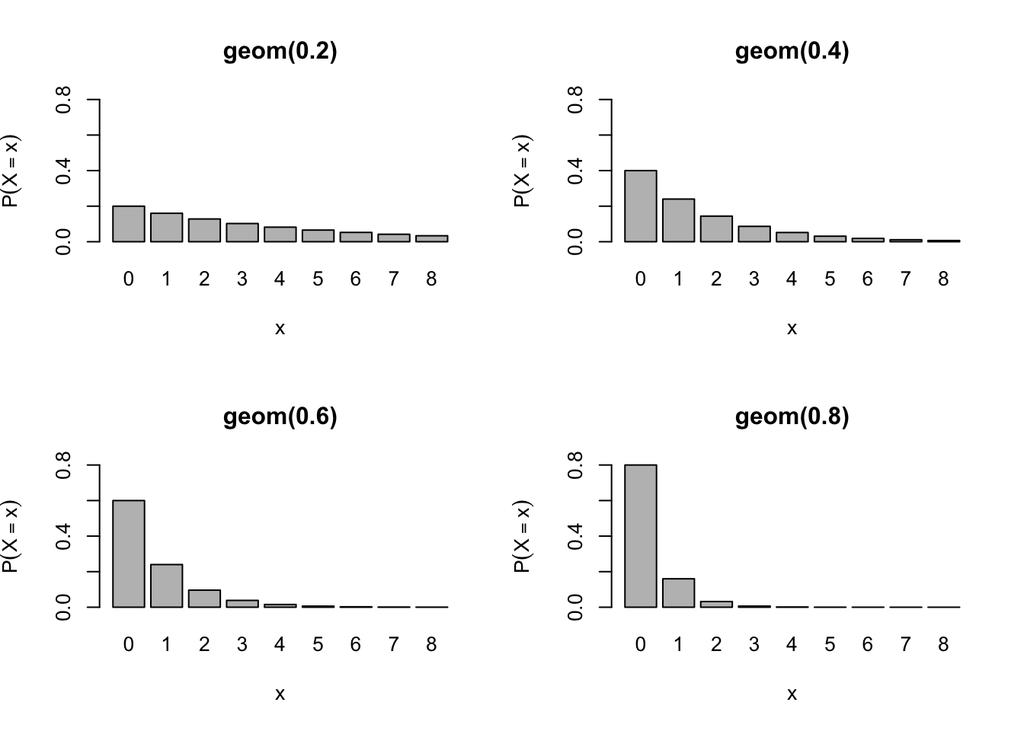

```r
n <- 8
x <- 0:n
myplot <- function(p) {
  barplot(dgeom(x,p),
          names.arg = x,
          ylim=c(0,.8),
          main=paste("geom(",p,")", sep=""),
          xlab="x",
          ylab=expression(P(X==x)))
}
par(mfrow=c(2,2))
for (p in c(.2,.4,.6,.8)) {
  myplot(p)
}
```

## Negative binomial

Despite the possibly confusing name, it is simply a generalised version of geometric distribution — instead of the first success, we wait until $r$ successes. Imagine doing independent $\mathrm{Bernoulli}(p)$ trials indefinitely until we see $r$ successes. Let $X$ denote the number of $0$ before getting $r$ number of $1$s. Then, $X\sim \text{nbinom}(r,p)$.

Conveniently, we may see $X\sim \text{nbinom}(r,p)$ as the sum of $r$ independent $\text{geom}(p)$ random variables. Thus, the mean and variance are particularly easy to compute:

$$\begin{align}
\mathbb{E}X &= r\frac{1-p}{p}\\
\operatorname{Var} X &= r\frac{1-p}{p^2}
\end{align}$$

To derive the PMF, note the following reasoning. If the $r$-th success is on trial $y$, then the previous $r-1$ successes can occur anywhere in the previous $y−1$ trials. Thus, there are $\binom{y-1}{r-1}$ ways we can get the $r$-th success on the $y$-th trial. Each of these ways has probability $(1-p)^{y-r}p^r$, so putting $x=y-r$, we get:
$$P(X=x) = \binom{r+x-1}{r-1}(1-p)^{x}p^r .$$

Here are some of PMF plots with varying $p$.

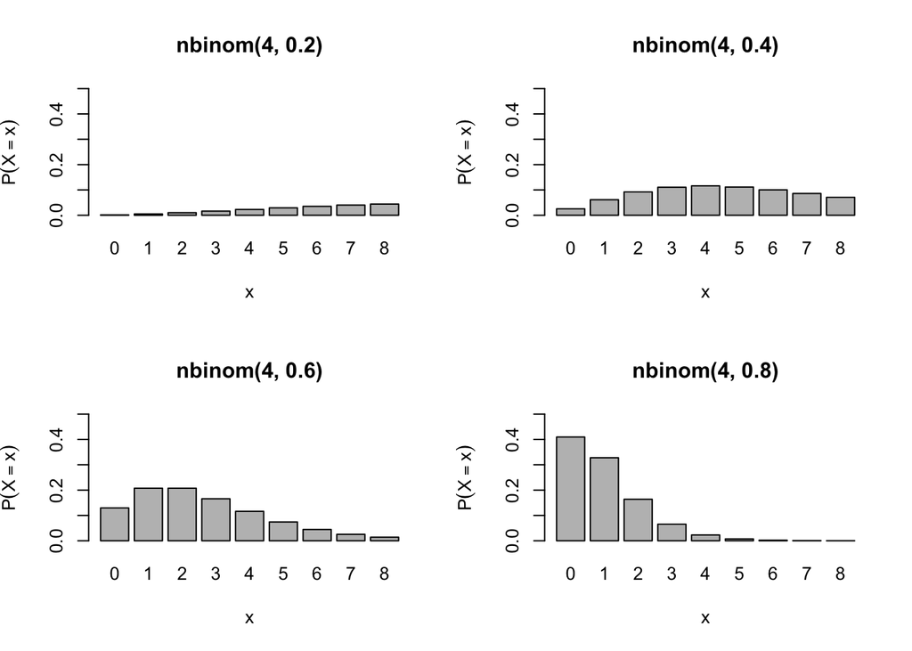

```r
n <- 8
x <- 0:n
myplot <- function(p) {
  barplot(dnbinom(x,4,p),
          names.arg = x,
          ylim=c(0,.5),
          main=paste("nbinom(",4,", ",p,")", sep=""),
          xlab="x",
          ylab=expression(P(X==x)))
}
par(mfrow=c(2,2))
for (p in c(.2,.4,.6,.8)) {
  myplot(p)
}
```

# Continuous distributions

R recognises common distributions by short names and specifies them by parameters.

| Distribution | R name | R Parameters | Abbreviation |
| --- | --- | --- | --- |
| Uniform | `unif` | `min`, `max` | $\mathrm{U}(a,b)$ |
| Exponential | `exp` | `rate` | $\exp(\lambda)$ |
| Weibull | `weibull` | `shape`, `scale` | $\mathrm{weibull}(m,\lambda)$ |
| Gamma | `gamma` | `shape`, `rate` | $\text{gamma}(m,\lambda)$ |
| Normal | `norm` | `mean`, `sd` | $\mathrm{N}(\mu,\sigma^2)$ |

R built-in functions for common distributions follow a certain pattern. Suppose that a distribution is recognised by name `xyz` and specified by parameters `p1` and `p2`, then R provides the following four functions to help you work with the distribution.

- `dxyz(x, p1, p2, ...)` returns $f(x)$, the value of PDF at $x$.
- `pxyz(q, p1, p2, ...)` returns $F(q)$, the value of CDF at $q$.
- `qxyz(p, p1, p2, ...)` returns $\operatorname{argmin}_x F(x)\geq p$, i.e., the [quantile function](https://en.wikipedia.org/wiki/Quantile_function).
- `rxyz(n, p1, p2, ...)` returns $n$ random samples.

The support of continuous $X$ is the set $\{x\in\mathbb{R} : f(x)>0\}$.

## Uniform

$X\sim \mathrm{U}(a,b)$ if the support of $X$ is an interval $[a,b]$ and the PDF is independent of location $x\in[a,b]$. Deriving the PDF of $X$ highlights key ideas common in many continuous distributions. The ideas to recall are:

- $f(x)$ is equal to $0$ for $x$ outside the support,
- $f(x)$ integrates to $1$ over the real line.

Given $X\sim \mathrm{U}(a,b)$, let $c=f(x)$ for $x\in[a,b]$. Then,
$$f(x) =
\begin{cases}
c & \text{if } x\in[a,b]\\
0 & \text{otherwise}
\end{cases}$$
It follows:

$$\begin{alignat}{2}
& & \int_\mathbb{R} f(x)dx &= 1\\
&\Leftrightarrow\quad & \int_a^b cdx &= 1\\
&\Leftrightarrow\quad & c(b-a) &= 1\\
&\Leftrightarrow\quad & c &= \frac{1}{b-a}
\end{alignat}$$

Just like the role $\mathrm{Bernoulli}(p)$ plays in constructing discrete distributions, as you will see in Sampling Methods, $\mathrm{U}(0,1)$ is a fundamental device for sampling from pretty much any distribution.

## Exponential

$X\sim \mathrm{exp}(\lambda)$ has the following PDF:
$$f(x) =
\begin{cases}
\lambda e^{-\lambda x} & \text{if } x\geq0\\
0 & \text{otherwise}
\end{cases}$$
with **rate** parameter $\lambda>0$. The CDF is equal to $0$ for $x<0$ and, for $x\geq0$,
$$\begin{align}
F(x) &= \int_{-\infty}^x f(t)dt\\
&= \int_0^x \lambda e^{-\lambda t} dt\\
&= 1-e^{-\lambda x}
\end{align}$$

In practice, $\mathrm{exp}(\lambda)$ is often used to model **waiting time**. For given waiting time $x$, large $\lambda$ implies fast arrival rate and high probability of arrival, indicated by $F(x)$ as an increasing function of $\lambda$. Clearly, given $\lambda$, the longer we wait (the larger $x$), the higher chance it arrives (the larger $F(x)$).

### Memoryless property

Unique to $\mathrm{exp}(\lambda)$ is the so-called momoryless property, which can be expressed as follows.
$$P(X>t+s | X>t) = P(X>s) \;\text{ for } s,t>0 .$$

A simple proof.
$$\begin{align}
P(X>t+s | X>t) &= \frac{P(X>t+s, X>t)}{P(X>t)}\\
&= \frac{P(X>t+s)}{P(X>t)}\\
&= \frac{e^{-\lambda(t+s)}}{e^{-\lambda(t)}}\\
&= e^{-\lambda s}\\
&= P(X>s)
\end{align}$$

To illustrate, let’s use $\mathrm{exp}(\lambda)$ to model the waiting time for an elevator. Suppose $\lambda = 0.5$. Then, the probability that an elevator arrives within 4 minutes, is $F(4) = 0.86$. Today is your bad day, and it has not come after waiting for 4 minutes. Now, you wonder “Since I already waited for so long and I know $F(5) = 0.92$, it will very likely come within a minute.” The memoryless property says “Not really. It will come only with $F(1) = 0.39$ chance.” In other words, if your mental model relies on $\mathrm{exp}(\lambda)$, the fact that you have already waited for so long is totally irrelevant.

## Weibull

When modelling arrival of bad things (e.g., mechanical failure or disaster), we often phrase it as **survival**, simply meaning the negation of arrival. In probabilistic terms, if $F(x)$ is the probability that a failure happens by the time $x$, $1-F(x)$ is the probability of survival until the time $x$.

While use of $\mathrm{exp}(\lambda)$ can be sufficient, $\mathrm{weibull}(m,\lambda)$ provides more general models, which are often more suitable for survival analysis. The PDF $f(x)$ and CDF $F(x)$ are given below.

$$\begin{align}
f(x) &=
\begin{cases}
m\lambda x^{m-1}e^{-\lambda x^m} & \text{if } x\geq0\\
0 & \text{otherwise}
\end{cases}\\\\
F(x) &=
\begin{cases}
1 - e^{-\lambda x^m} & \text{if } x\geq0\\
0 & \text{otherwise}
\end{cases}\\\\
\end{align}$$

$\mathrm{weibull}(m,\lambda)$ generalises $\mathrm{exp}(\lambda)$ to model waiting time with a time-varying arrival rate. Weibull distribution can also be specified by the **hazard function** $\lambda(x) = m\lambda x^{m-1}$.

### Hazard function

The hazard function characterises probabilistic models used in [survival analysis](https://en.wikipedia.org/wiki/Survival_analysis), and can be defined as follows.
$$\lambda(x) = \lim_{\Delta x \to 0} \frac{P(x<X\leq x+\Delta x|X>x)}{\Delta x}.$$
It is a rate of failure **given that it survived until $x$**. It is similar to the PDF, which is not conditioned on the survival until $x$. Observe,
$$\begin{align}
\lambda(x) &= \lim_{\Delta x \to 0} \frac{P(x<X\leq x+\Delta x|X>x)}{\Delta x}\\
&= \lim_{\Delta x \to 0} \frac{P(x<X\leq x+\Delta x, X>x)}{\Delta x P(X>x)}\\
&= \lim_{\Delta x \to 0} \frac{P(x<X\leq x+\Delta x)}{\Delta x}\frac{1}{P(X>x)}\\
&= \lim_{\Delta x \to 0} \frac{F(x+\Delta x)-F(x)}{\Delta x}\frac{1}{1-F(x)}\\
&= \frac{F'(x)}{1-F(x)}\\
&= \frac{f(x)}{1-F(x)}.
\end{align}$$

If $\lambda(x) = m\lambda x^{m-1}$, we have the following differential equation
$$m\lambda x^{m-1} = \frac{F'(x)}{1-F(x)}.$$
As you can check, the CDF for Weibull distribution is a solution.

Think about chance of death in life. When we are born, the rate of arrival is captured by the PDF. In contrast, as we get older, the rate of arrival is captured by the hazard function. As you can imagine, a constant hazard function used in $\mathrm{exp}(\lambda)$ is restrictive in many applications of survival analysis.

### R parameterisation

R parameterisation of the Weibull distribution differs from that presented here. `shape` parameter in R simply corresponds to $m$. But, `scale` in R corresponds to $\lambda^{-1/m}$.

For example, to simulate $\mathrm{weibull}(m,\lambda)$ with $m=0.5$ and $\lambda=2$, give

- `shape=0.5`
- `scale=2^(-1/0.5)`

to each of R built-in functions for $\mathrm{weibull}(m,\lambda)$.

## Gamma

$\mathrm{exp}(\lambda)$ is commonly used to model waiting time over the continuous time line. Suppose instead we divide the continuous time line into small intervals of equal length. Then, we can also model waiting-time problems using $\text{geom}(p)$, which is a sequence of independent $\text{Bernoulli}(p)$. That is, at each interval, an arrival occurs with probability $p$.

Remember that if we add $r$ number of independent $\text{geom}(p)$, we get $\text{nbinom}(r,p)$. It is natural to wonder what if we add $m$ number of independent $\text{exp}(\lambda)$. The answer is $\text{gamma}(m,\lambda)$. Now, let
$$X = Y_1+\dots+Y_m$$
where
$$Y_i\sim\text{exp}(\lambda),\; \forall i\in\{1,\dots,m\}.$$
Then,
$$X \sim \text{gamma}(m,\lambda).$$

These interesting interconnections are discussed in greater depth in Poisson Process.

Including more general cases of $m\in\mathbb{R}_{>0}$, the PDF $f(x)$ is:
$$f(x) = \frac{\lambda^m}{\Gamma(m)}x^{m-1}e^{-\lambda x} \mathbb{1}_{x>0}(x),$$
where $\Gamma$ denotes the [gamma function](https://en.wikipedia.org/wiki/Gamma_function), which has a property of $\Gamma(m) = (m-1)!$ for $m\in\mathbb{Z}_{>0}$.

## Normal

Largely because of its incredible analytical properties, normal distribution is arguably the most important probability distribution. To highlight just two of those properties, we use a random vector which is jointly distributed as normal. Let $\boldsymbol{\mu}$ denote the mean vector of length $n$ and $\mathbf{\Sigma}$ denote the $n\times n$ covariance matrix (hence, positive-semidefinite).

### Property 1

Let $\mathbf{Z}$ be the standardised $\mathbf{X}$, namely, $\mathbf{Z}\sim \mathrm{N}(\mathbf{0},\mathbf{I}_m)$ where $\mathbf{I}_m$ is the $m\times m$ identity matrix. Then, there exists a $n\times m$ matrix $\mathbf{A}$ such that $\mathbf{A}\mathbf{A}^T=\mathbf{\Sigma}$ and
$$\mathbf{X} = \mathbf{A}\mathbf{Z}+\boldsymbol{\mu} .$$

An implication is that since $\mathbf{Z}$ is merely $m$ independent $\mathrm{N}(0,1)$ stacked as a vector, it is easy to simulate $\mathbf{Z}$ and thereby simulating $\mathbf{X}$.

To generate a sample $\mathbf{x}$ of $\mathbf{X}$ with your desirable $\boldsymbol{\mu}$ and $\mathbf{\Sigma}$,

1. Decompose $\mathbf{\Sigma}$ into $\mathbf{A}$ and $\mathbf{A}^T$ (typically via Cholesky decomposition),
2. Simulate $\mathrm{N}(0,1)$ $n$ times and stack them as $\mathbf{z}$, and
3. Compute $\mathbf{x} = \mathbf{A}\mathbf{z}+\boldsymbol{\mu}$.

> Yes, of course, there’s a package for that! But, it is quite fulfilling to know a sampling algorithm for such an important random vector. Once you get it and test your own, you may use function `mvrnorm` from `MASS` package.

### Property 2

The second property is, in words, a linear transformation of $\mathbf{X}$ is also normal. Let $\mathbf{C}$ be a $m\times n$ matrix. Then,
$$\mathbf{C}\mathbf{X} \sim \mathrm{N}(\mathbf{C}\boldsymbol{\mu}, \mathbf{C}\mathbf{\Sigma}\mathbf{C}^T) .$$

For example, if $\mathbf{C} = (c_1\;c_2\;\dots\;c_n)$ is a $1\times n$ matrix, then we have the sum
$$\mathbf{C}\mathbf{X} = c_1X_1+c_2X_2+\dots+c_nX_n.$$

### Joint PDF

If $\mathbf{\Sigma}$ is a $n\times n$ positive-definite, then normal random vector $\mathbf{X} \sim \mathrm{N}(\boldsymbol{\mu},\mathbf{\Sigma})$ has the joint PDF:
$$f(\mathbf{x}) = (2\pi)^{-\frac{n}{2}}|\mathbf{\Sigma}|^{-\frac{1}{2}}\exp\left(-\frac{1}{2}(\mathbf{x}-\boldsymbol{\mu})^T\mathbf{\Sigma}^{-1}(\mathbf{x}-\boldsymbol{\mu})\right)$$
where $|\mathbf{\Sigma}|$ is the determinant of $\mathbf{\Sigma}$.